# Decision Trees

Decision trees are among the most common and useful machine learning methodologies. While they are a relatively simple method, they are incredibly easy to understand and implement for both classification and regression problems.

A decision tree “grows” by creating a cutoff point (often called a split) at a single point in the data that maximizes accuracy. The tree’s prediction is then based on the mean of the region that results from the input data.

For both regression and classification trees, it is important to optimize the number of splits that we allow the tree to make. If there is no limit, the trees would be able to create as many splits as the data will allow. This would mean the tree could perfectly “predict” every value from the training dataset, but would perform terribly out of sample. As such, it is important to keep a reasonable limit on the number of splits.

For regression trees, the decision to split along a continuum of values is often made by minimizing the residual sum of squares:

$$minimize \sum(y-prediciton)^2$$
This should be highly reminicent of ordinary least squares. Where this differs is in the number of splits created, the binary nature of the splits, and its nonlinear nature.

The methodology behind classificiation is very similar, except the splits are decided by minmimzing purity, such as the Gini index:

$$G= 1 - \sum_{i = 1}^{C} (p_{i})^2$$

The goal here is to create regions with as of classifications as possible, as such, a smaller Gini index implies a more pure region.

## Keep in Mind

- While decision trees are easy to interpret and understand, they often underpreform relative to other machine learning methodologies.
- Even though they may not offer the best predictions, decision trees excel at identifying key variables in the data.

## Also Consider

- Decision trees are the basis for all tree-based methodologies. More robust methods, such as random forests, are a collection of decision trees that aggregate their decisions into a single prediction. These forests are often more useful for predictive modeling.

# Implementations

## R

```r
rm(list=ls())
set.seed(1234)
# We will utilize data regarding passengers on their survival. We have multiple pieces of information on every passenger, including passenger age, sex, cabin number, and class.

# Our goal is to build a decision tree that can predict whether or not passengers survived the wreck.

# Read in the data

titanic <- read.csv("C:/Users/Evanm/Documents/titanic.csv")

# The data is clean for the most part, but some variables have been read in as factors instead of numeric variables, so we can fix that with the following code.
titanic$age <- as.numeric(titanic$age)
titanic$fare <- as.numeric(titanic$fare)

# As with all machine learning methodologies, we want to create a test and a training dataset

# Take a random sample of the data, here we have chosen to use 75% for training and 25% for validation
samp_size <- floor(0.75*nrow(titanic))
train_index <- sample(seq_len(nrow(titanic)),size=samp_size,replace=FALSE)

train <- titanic[train_index, ]
test <- titanic[-train_index, ]

# Now that we have our test and train datasets, we can build our trees. Here, we will use the package "rpart". Other packages, such as "ranger" are also viable options.

# install.packages("rpart") ## already installed
# install.packages("rpart.plot") ## already loaded
# install.packages("rattle") ## already loaded
# install.packages("caret") ## already loaded
library(rpart)
library(rpart.plot)
library(rattle)
library(caret)
# Here we can pick some variables we think would be good, the tree will decide which ones are best. Some data we have isn't useful, such as an individual's name or the random ID we assigned passengers, so there is no need to include them.

basic_tree <- rpart(
  survived ~ pclass + sex + age + fare + embarked, # our formula
  data=train,
  method = "class", # tell the model we are doing classification
  minsplit=2, # set a minimum number of splits
  cp=.02 # set a penalty rate. It is often useful to try out many different ones!
)

basic_tree
```

```
## n= 981
##
## node), split, n, loss, yval, (yprob)
##       * denotes terminal node
##
##  1) root 981 375 0 (0.61773700 0.38226300)
##    2) sex=male 631 121 0 (0.80824089 0.19175911) *
##    3) sex=female 350  96 1 (0.27428571 0.72571429)
##      6) pclass>=2.5 166  82 0 (0.50602410 0.49397590)
##       12) embarked=S 97  39 0 (0.59793814 0.40206186) *
##       13) embarked=C,Q 69  26 1 (0.37681159 0.62318841) *
##      7) pclass< 2.5 184  12 1 (0.06521739 0.93478261) *
```

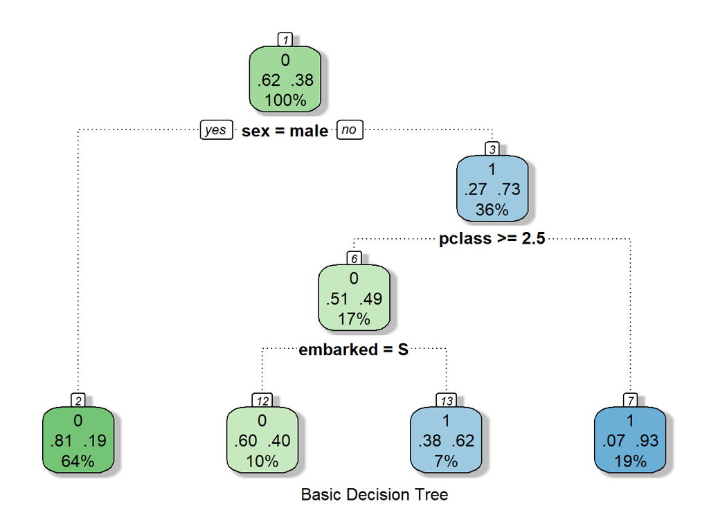

```r
# plot it using the packages we loaded above
fancyRpartPlot(basic_tree,caption="Basic Decision Tree")
```

```r
# Now we should predict using the test data we left out!
predictions <- predict(basic_tree,newdata=test,type="class")

# Make the numeric responses as well as the variables that we are testing on into factors
predictions <- as.factor(predictions)
test$survived <- as.factor(test$survived)

# Create a confusion matrix which tells us how well we did.
confusionMatrix(predictions,test$survived)
```

```
## Confusion Matrix and Statistics
##
##           Reference
## Prediction   0   1
##          0 192  52
##          1  11  73
##
##                Accuracy : 0.8079
##                  95% CI : (0.7611, 0.8491)
##     No Information Rate : 0.6189
##     P-Value [Acc > NIR] : 1.066e-13
##
##                   Kappa : 0.5654
##
##  Mcnemar's Test P-Value : 4.667e-07
##
##             Sensitivity : 0.9458
##             Specificity : 0.5840
##          Pos Pred Value : 0.7869
##          Neg Pred Value : 0.8690
##              Prevalence : 0.6189
##          Detection Rate : 0.5854
##    Detection Prevalence : 0.7439
##       Balanced Accuracy : 0.7649
##
##        'Positive' Class : 0
##
```

```r
# This particular model got ~75-80% accuracy. This varies each time if you do not set a seed. Much better than a coin toss, but not great. With some additional tuning a decision tree can be much more accurate! Try it for yourself by changing the factors that go into the prediction and the penalty rates.
```